# H&M Personalized Fashion Recommendations

by Mercy Nyambura Kariuki

# Introduction

H&M Group is a family of brands and businesses with 53 online markets and approximately 4,850 stores. Our online store offers shoppers an extensive selection of products to browse through. But with too many choices, customers might not quickly find what interests them or what they are looking for, and ultimately, they might not make a purchase. To enhance the shopping experience, product recommendations are key. More importantly, helping customers make the right choices also has a positive implications for sustainability, as it reduces returns, and thereby minimizes emissions from transportation.

In this Kaggle competition, H&M Group invites you to develop product recommendations based on data from previous transactions, as well as from customer and product meta data. The available meta data spans from simple data, such as garment type and customer age, to text data from product descriptions, to image data from garment images.

There are no preconceptions on what information that may be useful – that is for you to find out. If you want to investigate a categorical data type algorithm, or dive into NLP and image processing deep learning, that is up to you.

This project consists of 3 datasets:

- articles: detailed metadata for each article_id available for purchase
- images: a folder of images corresponding to each article_id; images are placed in subfolders starting with the first three digits of the article_id; note, not all article_id values have a corresponding image.
- customers - metadata for each customer_id in dataset
- transactions_train - the training data, consisting of the purchases each customer for each date, as well as additional information. Duplicate rows correspond to multiple purchases of the same item. Your task is to predict the article_ids each customer will purchase during the 7-day period immediately after the training data period.

Stages of the project

1. Data Aquisition

2. Data Preprocessing

3. ExploratoryDataAnalysis

4. Portrait of the user of each region

5. Research Results

# Stage 1. Data acquisition

> **Let's examine the data provided for the project.**

```python
#import the libraries
import numpy as np
import pandas as pd
import seaborn as sns
import matplotlib.pyplot as plt

%matplotlib inline
```

```python
articles = pd.read_csv('C:/Users/kariu/OneDrive/Desktop/Data Science/H&M Product Recommendation/articles.csv')
customers = pd.read_csv('C:/Users/kariu/OneDrive/Desktop/Data Science/H&M Product Recommendation/customers.csv')
transactions=pd.read_csv('C:/Users/kariu/OneDrive/Desktop/Data Science/H&M Product Recommendation/transactions_train.csv')
```

> **Getting a sample of each table.**

```python
articles.sample()
```

|  | article_id | product_code | prod_name | product_type_no | product_type_name | product_group_name | graphical_appearance_no | graphical_appearance_name | colour_group_code | colour_group_name | ... | department_name | index_code | index_name | index_group_no | index_group_name | section_no | section_name | garment_group_no | garment_group_name | detail_desc |
| --- | --- | --- | --- | --- | --- | --- | --- | --- | --- | --- | --- | --- | --- | --- | --- | --- | --- | --- | --- | --- | --- |
| 56800 | 715042005 | 715042 | Baseball Tee | 255 | T-shirt | Garment Upper body | 1010005 | Colour blocking | 43 | Dark Red | ... | Light Basic Jersey | F | Menswear | 3 | Menswear | 26 | Men Underwear | 1002 | Jersey Basic | T-shirt in jersey made from a cotton blend wit... |

1 rows × 25 columns

```python
customers.sample()
```

|  | customer_id | FN | Active | club_member_status | fashion_news_frequency | age | postal_code |
| --- | --- | --- | --- | --- | --- | --- | --- |
| 660936 | 7b5fe6c4fd333fe4c5403e821a189ea13e4f86243ead1b... | NaN | NaN | ACTIVE | NONE | 23.0 | f1d3119d6335cb3b34846c0f7257873be979f13843e27b... |

```python
transactions.sample()
```

|  | t_dat | customer_id | article_id | price | sales_channel_id |
| --- | --- | --- | --- | --- | --- |
| 499013 | 2018-09-29 | 9701dd9136d1c21f8991736ddd91d33a6790d94608041d... | 552018007 | 0.027119 | 1 |

> **Let's get general information about each table**

```python
articles.info()
```

```
<class 'pandas.core.frame.DataFrame'>
RangeIndex: 105542 entries, 0 to 105541
Data columns (total 25 columns):
 #   Column                        Non-Null Count   Dtype
---  ------                        --------------   -----
 0   article_id                    105542 non-null  int64
 1   product_code                  105542 non-null  int64
 2   prod_name                     105542 non-null  object
 3   product_type_no               105542 non-null  int64
 4   product_type_name             105542 non-null  object
 5   product_group_name            105542 non-null  object
 6   graphical_appearance_no       105542 non-null  int64
 7   graphical_appearance_name     105542 non-null  object
 8   colour_group_code             105542 non-null  int64
 9   colour_group_name             105542 non-null  object
```

[output cut: 17 more lines]

```python
customers.info()
```

```
<class 'pandas.core.frame.DataFrame'>
RangeIndex: 1371980 entries, 0 to 1371979
Data columns (total 7 columns):
 #   Column                  Non-Null Count    Dtype
---  ------                  --------------    -----
 0   customer_id             1371980 non-null  object
 1   FN                      476930 non-null   float64
 2   Active                  464404 non-null   float64
 3   club_member_status      1365918 non-null  object
 4   fashion_news_frequency  1355971 non-null  object
 5   age                     1356119 non-null  float64
 6   postal_code             1371980 non-null  object
dtypes: float64(3), object(4)
memory usage: 73.3+ MB
```

```python
transactions.info()
```

```
<class 'pandas.core.frame.DataFrame'>
RangeIndex: 31788324 entries, 0 to 31788323
Data columns (total 5 columns):
 #   Column            Dtype
---  ------            -----
 0   t_dat             object
 1   customer_id       object
 2   article_id        int64
 3   price             float64
 4   sales_channel_id  int64
dtypes: float64(1), int64(2), object(2)
memory usage: 1.2+ GB
```

> **The number of values in each table varies indicating that there are null values. Let's see how many null value are there**

```python
articles.isnull().sum()
```

```
article_id                        0
product_code                      0
prod_name                         0
product_type_no                   0
product_type_name                 0
product_group_name                0
graphical_appearance_no           0
graphical_appearance_name         0
colour_group_code                 0
colour_group_name                 0
perceived_colour_value_id         0
perceived_colour_value_name       0
perceived_colour_master_id        0
perceived_colour_master_name      0
department_no                     0
department_name                   0
index_code                        0
index_name                        0
index_group_no                    0
index_group_name                  0
section_no                        0
section_name                      0
garment_group_no                  0
garment_group_name                0
detail_desc                     416
dtype: int64
```

```python
transactions.isnull().sum()
```

```
t_dat               0
customer_id         0
article_id          0
price               0
sales_channel_id    0
dtype: int64
```

```python
customers.isnull().sum()
```

```
customer_id                    0
FN                        895050
Active                    907576
club_member_status          6062
fashion_news_frequency     16009
age                        15861
postal_code                    0
dtype: int64
```

```python
articles.shape
```

```
(105542, 25)
```

```python
customers.shape
```

```
(1371980, 7)
```

```python
transactions.shape
```

```
(31788324, 5)
```

> - In the articles table, we have 416 null values in the detail description column.
> - The transactions table has no null values.
> - The customers table has a significant number of null values in each column except `customer_id` and `postal_code`

> **Let's see if there are any duplicates in the tables**

```python
articles.duplicated().sum()
```

```
0
```

```python
customers.duplicated().sum()
```

```
0
```

```python
transactions.duplicated().sum()
```

```
2974905
```

- The articles and customers dataset shows no records of duplicates while transactions shows 2,974,905 duplicates which represents 9.4% of all the transactions recorded

# Stage 2: Data Preprocessing

# Articles Analysis

## Univariate Articles Exploration

```python
articles.corr()
```

|  | article_id | product_code | product_type_no | graphical_appearance_no | colour_group_code | perceived_colour_value_id | perceived_colour_master_id | department_no | index_group_no | section_no | garment_group_no |
| --- | --- | --- | --- | --- | --- | --- | --- | --- | --- | --- | --- |
| article_id | 1.000000 | 1.000000 | -0.029674 | 0.007993 | -0.064497 | -0.048664 | 0.010208 | -0.077247 | -0.047474 | -0.044521 | -0.013408 |
| product_code | 1.000000 | 1.000000 | -0.029674 | 0.007993 | -0.064497 | -0.048664 | 0.010208 | -0.077247 | -0.047474 | -0.044521 | -0.013408 |
| product_type_no | -0.029674 | -0.029674 | 1.000000 | -0.001438 | 0.077929 | -0.046910 | -0.049135 | -0.001921 | 0.067162 | -0.118532 | -0.461593 |
| graphical_appearance_no | 0.007993 | 0.007993 | -0.001438 | 1.000000 | 0.016824 | 0.026956 | 0.019440 | -0.000316 | 0.004883 | 0.011345 | 0.013072 |
| colour_group_code | -0.064497 | -0.064497 | 0.077929 | 0.016824 | 1.000000 | 0.066724 | -0.177083 | 0.119798 | 0.035616 | 0.032955 | -0.000316 |
| perceived_colour_value_id | -0.048664 | -0.048664 | -0.046910 | 0.026956 | 0.066724 | 1.000000 | 0.027785 | 0.009986 | 0.032685 | -0.004332 | 0.020732 |
| perceived_colour_master_id | 0.010208 | 0.010208 | -0.049135 | 0.019440 | -0.177083 | 0.027785 | 1.000000 | -0.017224 | -0.035996 | -0.002461 | -0.022573 |
| department_no | -0.077247 | -0.077247 | -0.001921 | -0.000316 | 0.119798 | 0.009986 | -0.017224 | 1.000000 | 0.453340 | 0.349181 | -0.053457 |
| index_group_no | -0.047474 | -0.047474 | 0.067162 | 0.004883 | 0.035616 | 0.032685 | -0.035996 | 0.453340 | 1.000000 | -0.077389 | -0.144313 |
| section_no | -0.044521 | -0.044521 | -0.118532 | 0.011345 | 0.032955 | -0.004332 | -0.002461 | 0.349181 | -0.077389 | 1.000000 | 0.217788 |
| garment_group_no | -0.013408 | -0.013408 | -0.461593 | 0.013072 | -0.000316 | 0.020732 | -0.022573 | -0.053457 | -0.144313 | 0.217788 | 1.000000 |

> **Let's see how many colors we have among the products sold**

```python
print(articles.perceived_colour_value_name.unique())
articles.loc[articles.perceived_colour_value_name == 'Undefined'] = 'Unknown'
print(articles.perceived_colour_value_name.unique())
```

```
['Dark' 'Light' 'Dusty Light' 'Medium Dusty' 'Bright' 'Medium' 'Undefined'
 'Unknown']
['Dark' 'Light' 'Dusty Light' 'Medium Dusty' 'Bright' 'Medium' 'Unknown']
```

> **There are 7 unique colors that exist among the products sold. Let's visualize this in a histogram**

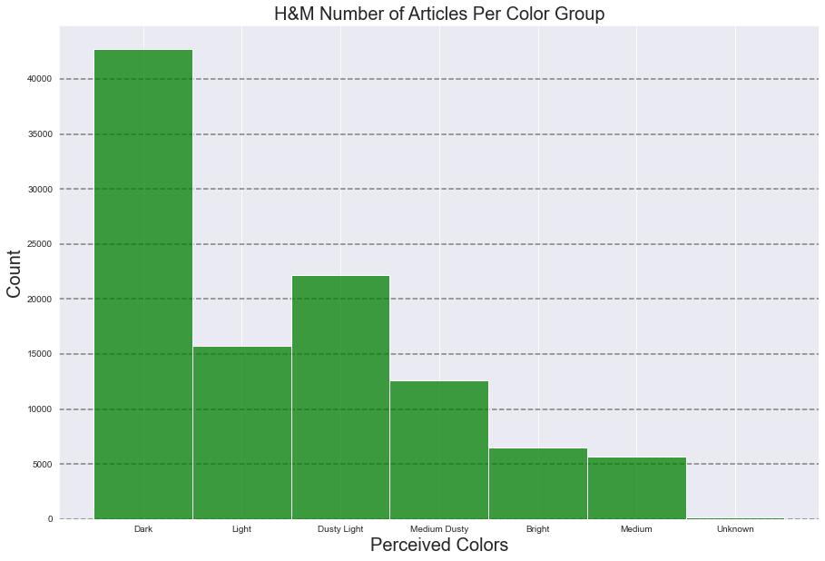

```python
sns.set_style('darkgrid')
plt.subplots(figsize = (15, 10))
sns.histplot(data = articles, x = 'perceived_colour_value_name', color = 'green')

# Add x label and format it
plt. xlabel('Perceived Colors', fontsize=20)

# Add y label and format it
plt.ylabel('Count', fontsize=20)

#Add title and format it
plt.title('H&M Number of Articles Per Color Group', fontsize=20)

plt.grid(axis="y",color = 'grey', linestyle = '--', linewidth = 1.5)

plt.show()
```

```python
articles.perceived_colour_value_name.value_counts()
```

```
Dark            42706
Dusty Light     22152
Light           15739
Medium Dusty    12630
Bright           6471
Medium           5711
Unknown           133
Name: perceived_colour_value_name, dtype: int64
```

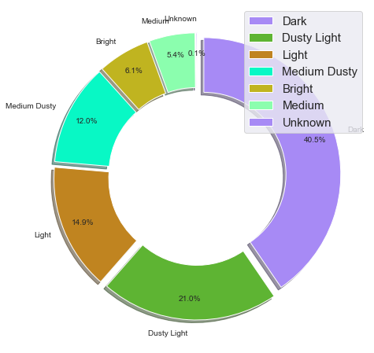

```python
#a78af5, #8bfeae, #5eb433, #c08420 ,#c0b420, #f36007
colors = ['#a78af5', '#5eb433','#c08420', '#08f8c5', '#c0b420', '#8bfeae']
labels=['Dark', 'Dusty Light', 'Light', 'Medium Dusty', 'Bright', 'Medium', 'Unknown']
sizes= [42706, 22152, 15739, 12630, 6471, 5711, 133]
explode = (0.05, 0.05, 0.05, 0.05, 0.05, 0.05, 0.05)
plt.figure(figsize=[8,8])
plt.pie(articles.perceived_colour_value_name.value_counts(),
        labels=labels,
        autopct='%1.1f%%',
        startangle=90,
        counterclock=False,
        wedgeprops={'width':0.4},
        colors=colors,
        shadow=True,
        pctdistance=0.85,
        explode=explode,);
plt.rcParams['font.size']=15
plt.legend();
```

> **From the above diagram, majority of H&M products are Dark, followed by Dusty Light and Light**

### Which articles are the best sellers?

```python
bestsellers = transactions.groupby('article_id').count().sort_values(by = 'customer_id', ascending = False)
bestsellers.head(5)
```

| article_id | t_dat | customer_id | price | sales_channel_id |
| --- | --- | --- | --- | --- |
| 706016001 | 50287 | 50287 | 50287 | 50287 |
| 706016002 | 35043 | 35043 | 35043 | 35043 |
| 372860001 | 31718 | 31718 | 31718 | 31718 |
| 610776002 | 30199 | 30199 | 30199 | 30199 |
| 759871002 | 26329 | 26329 | 26329 | 26329 |

```python
50287/365
```

```
137.77260273972604
```

```python
26329/365
```

```
72.13424657534246
```

#### The topseller article has an average of sales have an average sales of ~137 units per day. The bestseller ranked #5 has an average sales of 72 units per day, which is more than half of the sales of the top bestseller

```python
sales = transactions.groupby('article_id').count()

def f(x):
    try:
        return sales.loc[x]['customer_id']
    except:
        return 0
articles['total_sales'] = articles['article_id'].apply(f)

#view a sample of the articles
articles.sample()
```

|  | article_id | product_code | prod_name | product_type_no | product_type_name | product_group_name | graphical_appearance_no | graphical_appearance_name | colour_group_code | colour_group_name | ... | index_code | index_name | index_group_no | index_group_name | section_no | section_name | garment_group_no | garment_group_name | detail_desc | total_sales |
| --- | --- | --- | --- | --- | --- | --- | --- | --- | --- | --- | --- | --- | --- | --- | --- | --- | --- | --- | --- | --- | --- |
| 43946 | 678691002 | 678691 | CARINA HIGH SUPPORT BRA | 306 | Bra | Underwear | 1010016 | Solid | 9 | Black | ... | S | Sport | 26 | Sport | 5 | Ladies H&M Sport | 1005 | Jersey Fancy | Sports bra in fast-drying functional fabric wi... | 3002 |

1 rows × 26 columns

```python
#drop unneccessary columns
to_drop = ['product_type_no',
          'graphical_appearance_no',
          'colour_group_code',
          'perceived_colour_value_id',
           'perceived_colour_master_id',
           'department_no',
           'index_code',
           'index_group_no',
           'section_no',
           'garment_group_no']

#check if the columns have been dropped
articles.drop(columns = to_drop, axis = 1, inplace = True)
```

```python
articles.sort_values(by = 'total_sales', ascending = False).sample()
```

|  | article_id | product_code | prod_name | product_type_name | product_group_name | graphical_appearance_name | colour_group_name | perceived_colour_value_name | perceived_colour_master_name | department_name | index_name | index_group_name | section_name | garment_group_name | detail_desc | total_sales |
| --- | --- | --- | --- | --- | --- | --- | --- | --- | --- | --- | --- | --- | --- | --- | --- | --- |
| 53519 | 704760001 | 704760 | Country socks | Socks | Socks & Tights | Solid | White | Light | White | Kids Dress-up/Football | Children Accessories, Swimwear | Baby/Children | Kids Accessories, Swimwear & D | Accessories | Fine-knit, knee-high football socks in fast-dr... | 22 |

```python
bestsellers = articles.sort_values(by='total_sales', ascending=False).head(1000)
```

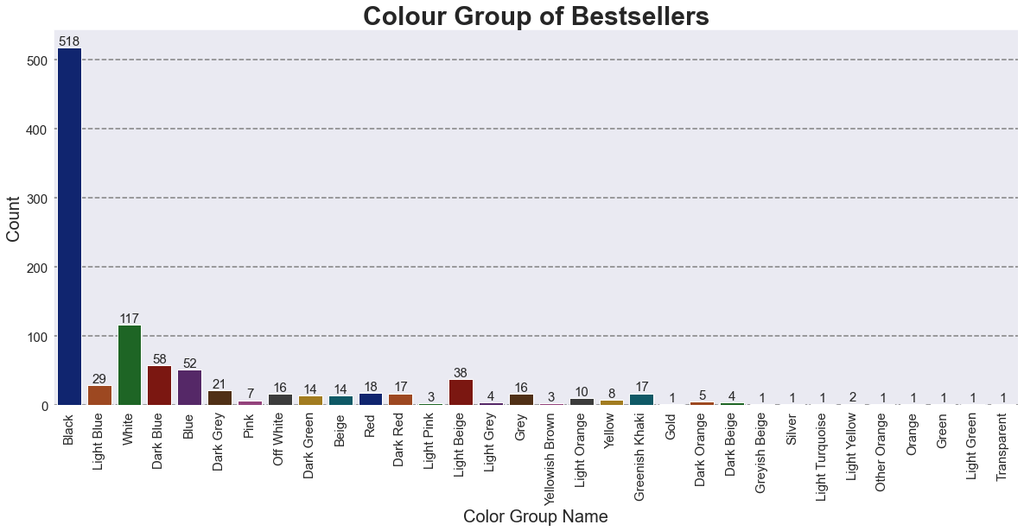

```python
plt.figure(figsize = (20,8))
g = sns.countplot(data = bestsellers,
                  x ="colour_group_name",
                  palette = "dark")
g.bar_label(g.containers[0])
g.tick_params(axis = "x", rotation = 90)

#Add title an format it
plt.title("Colour Group of Bestsellers", fontsize=30, weight="bold")

# Add x label and format it
plt.xlabel("Color Group Name", fontsize=20)

# Add y label and format it
plt.ylabel("Count", fontsize=20)


plt.grid(axis="y",color = 'grey', linestyle = '--', linewidth = 1.5)

plt.show(g)
```

> **It is observed that black is the most popular color followed by White. Black entails 51% of the colors purchased followed by White which is 11.7%**

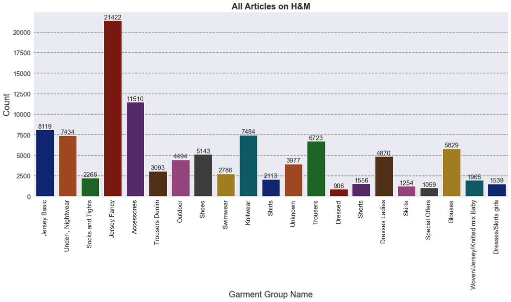

```python
plt.figure(figsize = (20,8))
a = sns.countplot(x="garment_group_name",
                 data = articles,
                 palette = "dark")
a.bar_label(a.containers[0])
a.tick_params(axis = "x", rotation=90)

#  Add title and format it
plt.title("All Articles on H&M", fontsize=20, weight="bold")

# Add x label and format it
plt.xlabel("Garment Group Name", fontsize=20)

# Add y label and format it
plt.ylabel("Count", fontsize=20)

plt.grid(axis="y",color = 'grey', linestyle = '--', linewidth = 1.5)

plt.show(a)
```

> **It is observed that the Jersey Facy is the most popular of the garments followed by Accesories. There a 2X gap between `Jersey Fancy` and `Accessories`.**

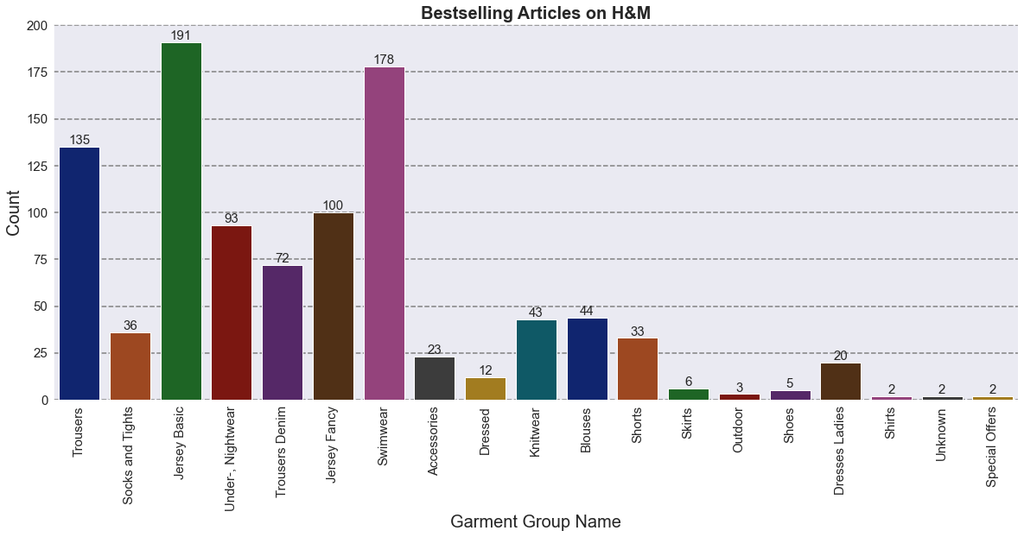

```python
plt.figure(figsize = (20, 8))
b = sns.countplot(x = "garment_group_name",
                 data = bestsellers,
                 palette = "dark")
b.bar_label(b.containers[0])
b.tick_params(axis = "x", rotation = 90)

# Add title and format it
plt.title("Bestselling Articles on H&M", fontsize=20, weight="bold")

# Add x label and format it
plt.xlabel("Garment Group Name", fontsize=20)

# Add y label and format it
plt.ylabel("Count", fontsize=20)

plt.grid(axis="y",color = 'grey', linestyle = '--', linewidth = 1.5)

plt.show(b)
```

> **Compared to what we observed earlier for the most popular garment in ALL the articles, here, the best selling articles on H&M, the most popular garment is the Jersey Basic followed by Swimwear. Unlike All Articles, Jersey Fancy is the 4th on the list**

> **Let's zoom out a bit and have a look at leading articles by index group name**

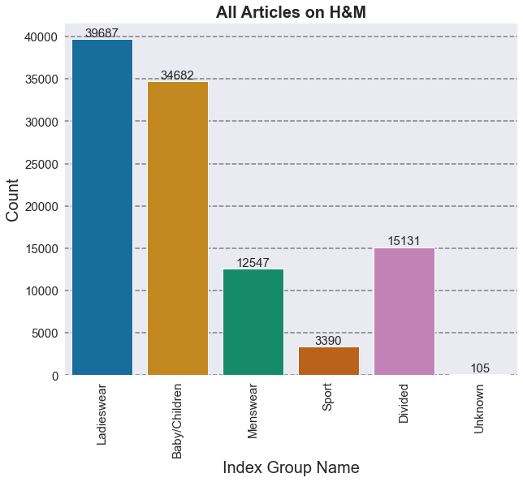

```python
plt.figure(figsize = (10,8))
c = sns.countplot(x="index_group_name",
                 data = articles,
                 palette = "colorblind")
c.bar_label(c.containers[0])
c.tick_params(axis = "x", rotation = 90)

# Add title
plt.title("All Articles on H&M", fontsize=20, weight="bold")


# Add y label
plt.ylabel("Count", fontsize=20)

# Ad x label
plt.xlabel("Index Group Name", fontsize=20)

plt.grid(axis="y",color = 'grey', linestyle = '--', linewidth = 1.5)

plt.show(c)
```

> **Among all the articles on H&M. Ladies wear and Children clothes contribute to 70.46% of the articles in the index group**

**Let's see which article is popular among the best selling articles**

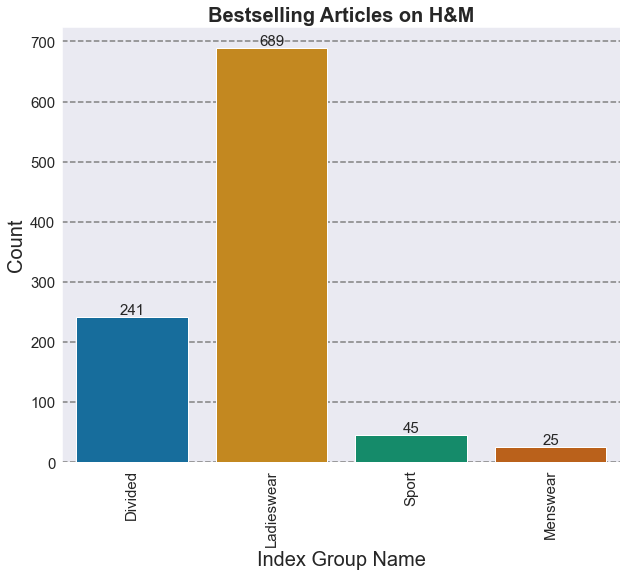

```python
plt.figure(figsize = (10,8))
d = sns.countplot(x = "index_group_name",
                 data = bestsellers,
                 palette = "colorblind")
d.bar_label(d.containers[0])
d.tick_params(axis = "x", rotation = 90)

#Add title and formatting
plt.title("Bestselling Articles on H&M", fontsize=20, weight="bold")

# Add x label
plt.xlabel("Index Group Name", fontsize=20)

# Add y label anf formatting
plt.ylabel("Count", fontsize=20)

plt.grid(axis="y",color = 'grey', linestyle = '--', linewidth = 1.5)

plt.show(d)
```

> **The graph shows that among the best selling articles, the ladies wear is leading which contributes to 68.9% of the best articles. Dividend seconds this by 1/3 of the ladieswear (24.1%)**

> **A quick review at the official H&M website shows that it targets the feminine styles. We can see that the most bestselling articles were designed for the female audience. It is therefore safe to conclude that most customers that contribute to the sales of H&M articles belong to the female demographic.**

> **Although H&M produces alot of Baby articles, none of them made it to the bestsellers**

## Bivariate Articles Exploration

## Customers Analysis

### Univariate Customer Analysis

```python
customers.drop_duplicates(inplace = True)
print(customers.info())
```

```
<class 'pandas.core.frame.DataFrame'>
Int64Index: 1371980 entries, 0 to 1371979
Data columns (total 7 columns):
 #   Column                  Non-Null Count    Dtype
---  ------                  --------------    -----
 0   customer_id             1371980 non-null  object
 1   FN                      476930 non-null   float64
 2   Active                  464404 non-null   float64
 3   club_member_status      1365918 non-null  object
 4   fashion_news_frequency  1355971 non-null  object
 5   age                     1356119 non-null  float64
 6   postal_code             1371980 non-null  object
dtypes: float64(3), object(4)
memory usage: 83.7+ MB
None
```

```python
customers.corr()
```

|  | FN | Active | age |
| --- | --- | --- | --- |
| FN | NaN | NaN | NaN |
| Active | NaN | NaN | NaN |
| age | NaN | NaN | 1.0 |

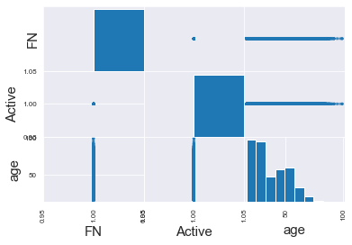

```python
pd.plotting.scatter_matrix(customers);
```

## **Who contributes to the bestsellers**

```python
print(list(customers.columns))
```

```
['customer_id', 'FN', 'Active', 'club_member_status', 'fashion_news_frequency', 'age', 'postal_code']
```

```python
bestsellers_transactions = transactions[transactions['article_id'].isin(bestsellers['article_id'])]
bestsellers_contributors = customers[customers['customer_id'].isin(bestsellers_transactions['customer_id'])]
bestsellers_contributors.head()
```

|  | customer_id | FN | Active | club_member_status | fashion_news_frequency | age | postal_code |
| --- | --- | --- | --- | --- | --- | --- | --- |
| 0 | 00000dbacae5abe5e23885899a1fa44253a17956c6d1c3... | NaN | NaN | ACTIVE | NONE | 49.0 | 52043ee2162cf5aa7ee79974281641c6f11a68d276429a... |
| 1 | 0000423b00ade91418cceaf3b26c6af3dd342b51fd051e... | NaN | NaN | ACTIVE | NONE | 25.0 | 2973abc54daa8a5f8ccfe9362140c63247c5eee03f1d93... |
| 2 | 000058a12d5b43e67d225668fa1f8d618c13dc232df0ca... | NaN | NaN | ACTIVE | NONE | 24.0 | 64f17e6a330a85798e4998f62d0930d14db8db1c054af6... |
| 4 | 00006413d8573cd20ed7128e53b7b13819fe5cfc2d801f... | 1.0 | 1.0 | ACTIVE | Regularly | 52.0 | 25fa5ddee9aac01b35208d01736e57942317d756b32ddd... |
| 5 | 000064249685c11552da43ef22a5030f35a147f723d5b0... | NaN | NaN | NaN | NaN | NaN | 2c29ae653a9282cce4151bd87643c907644e09541abc28... |

> **Let's see which age contributes to the best sellers among all the customers**

```python
customers['age'].value_counts()
```

```
21.0    67530
24.0    56124
20.0    55196
25.0    54989
23.0    54867
        ...
98.0        7
97.0        4
93.0        4
96.0        3
94.0        3
Name: age, Length: 84, dtype: int64
```

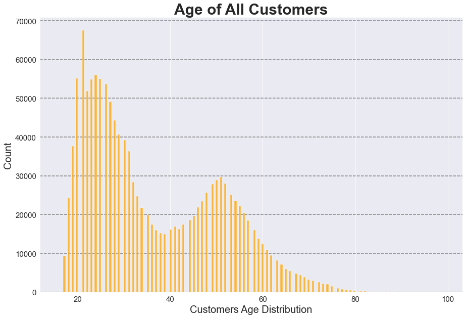

```python
#Age Distribution
sns.set_style('darkgrid')
plt.figure(figsize = (15,10))
sns.histplot(customers['age'],
            kde = False,
            color = "orange")

# x and y labels
plt.xlabel('Customers Age Distribution', fontsize=20)
plt.ylabel('Count', fontsize=20)

# plot title
plt.title("Age of All Customers", fontsize=30, weight='bold')

plt.grid(axis="y",color = 'grey', linestyle = '--', linewidth = 1.5)

plt.show()
```

> **We can see that 21 year olds really love buying H&M products. We can also see another peak among 51 year olds**

> **Let's see which age of customers contribute to the best sellers**

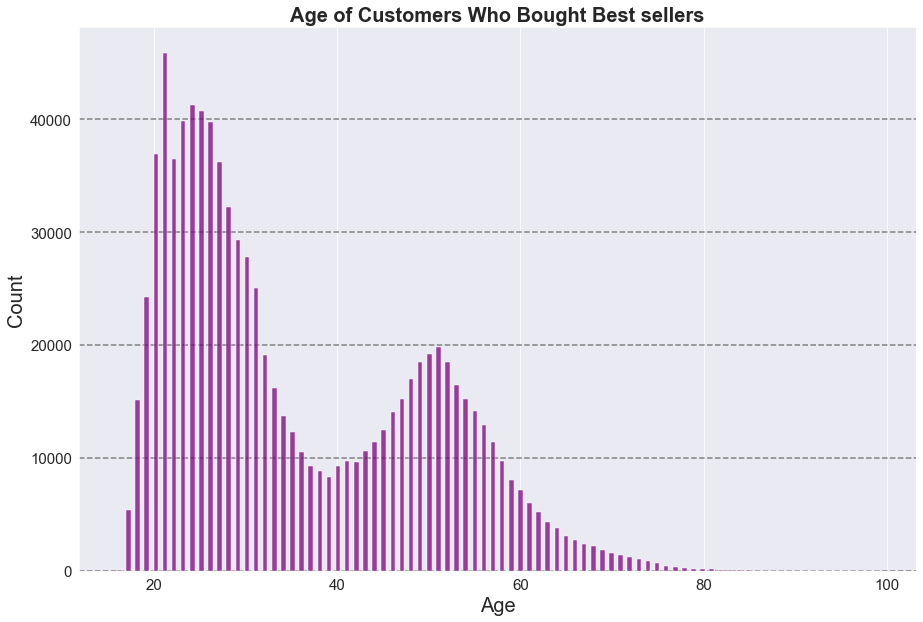

```python
sns.set_style('darkgrid')
plt.figure(figsize = (15,10))
sns.histplot(bestsellers_contributors['age'],
             kde = False,
            color = "purple")

# Add title and formatting
plt.title("Age of Customers Who Bought Best sellers", fontsize=20, weight="bold")

# Add x label and formatting
plt.xlabel("Age", fontsize=20)

# Add y label and formatting
plt.ylabel("Count", fontsize=20)

plt.grid(axis="y",color = 'grey', linestyle = '--', linewidth = 1.5)

plt.show()
```

> **We have a similar observation of all customers among the customers contributing to the best sellers. We have a surge among the 21 yrs old and another peak observation among the 50years olds**

```python
bestsellers_contributors['age'].value_counts()
```

```
21.0    45848
24.0    41254
25.0    40748
23.0    39823
26.0    39756
        ...
95.0        5
93.0        4
97.0        2
94.0        1
96.0        1
Name: age, Length: 84, dtype: int64
```

## Which articles generate the most revenue

```python
transactions.columns
```

```
Index(['t_dat', 'customer_id', 'article_id', 'price', 'sales_channel_id'], dtype='object')
```

```python
article_revenue = transactions.groupby('article_id').sum()
article_revenue.drop(columns=['sales_channel_id'], inplace=True)
article_revenue_ranking = article_revenue.sort_values(by='price', ascending=False)
article_revenue_ranking.rename(columns={'price':'total_revenue'}, inplace=True)
article_revenue_ranking.head(10)
```

| article_id | total_revenue |
| --- | --- |
| 706016001 | 1631.732102 |
| 706016002 | 1136.321085 |
| 568601006 | 939.268593 |
| 448509014 | 781.478390 |
| 706016003 | 692.195915 |
| 399223001 | 686.484780 |
| 720125001 | 683.606542 |
| 562245046 | 656.213763 |
| 751471001 | 590.639949 |
| 562245001 | 535.719898 |

> **The first two articles correspond to the top 2 bestsellers.**

```python
articles.columns
```

```
Index(['article_id', 'product_code', 'prod_name', 'product_type_name',
       'product_group_name', 'graphical_appearance_name', 'colour_group_name',
       'perceived_colour_value_name', 'perceived_colour_master_name',
       'department_name', 'index_name', 'index_group_name', 'section_name',
       'garment_group_name', 'detail_desc', 'total_sales'],
      dtype='object')
```

```python
#add revenue data
article_revenue = transactions.groupby('article_id').sum()

def g(x):
    try:
        return article_revenue.loc[x]['price']
    except:
        return 0
articles['total_revenue'] = articles['article_id'].apply(f)
articles.sample()
```

|  | article_id | product_code | prod_name | product_type_name | product_group_name | graphical_appearance_name | colour_group_name | perceived_colour_value_name | perceived_colour_master_name | department_name | index_name | index_group_name | section_name | garment_group_name | detail_desc | total_sales | total_revenue |
| --- | --- | --- | --- | --- | --- | --- | --- | --- | --- | --- | --- | --- | --- | --- | --- | --- | --- |
| 55065 | 709027002 | 709027 | LOGG Brienne | Jacket | Garment Upper body | Solid | Greenish Khaki | Medium Dusty | Khaki green | Outwear | Ladieswear | Ladieswear | H&M+ | Outdoor | Long parka in a cotton weave with a stand-up c... | 287 | 287 |

> **Let's see the top performers**

```python
top_performers = articles.sort_values(by='total_revenue', ascending=False)
articles['bestseller_revenue'] = articles['article_id'].isin(top_performers['article_id']).astype(int) * articles['article_id'].isin(bestsellers['article_id']).astype(int)
```

```python
print("Number of articles that are both bestselling and top performing:", articles['bestseller_revenue'].sum())
```

```
Number of articles that are both bestselling and top performing: 1000
```

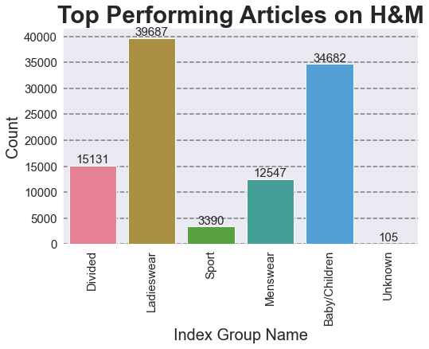

```python
plt.figure(figsize=(8,5))
g = sns.countplot(x="index_group_name",
                  data=top_performers,
                  palette="husl")
g.bar_label(g.containers[0])
g.tick_params(axis='x', rotation=90)

#plot title
plt.title('Top Performing Articles on H&M', fontsize=30, weight="bold")

# x and y labels
plt.xlabel('Index Group Name', fontsize=20)
plt.ylabel('Count', fontsize=20)

plt.grid(axis="y",color = 'grey', linestyle = '--', linewidth = 1.5)

plt.show(g)
```

> **Ladieswear and children wear are the the top articles of H&M products**

### Bivariate Customer Analysis

## Let's see if the sales and revenues are correlated

```python
articles['total_sales'].corr(articles['total_revenue'])
```

```
0.9999999999999999
```

## Revenue by Index Group Name

### Which Index Group has the highest sales?

```python
index_group_revenue = articles[['index_group_name','total_revenue']].groupby('index_group_name').total_revenue.sum().reset_index()
index_group_revenue
```

|  | index_group_name | total_revenue |
| --- | --- | --- |
| 0 | Baby/Children | 1216615 |
| 1 | Divided | 7135322 |
| 2 | Ladieswear | 20397998 |
| 3 | Menswear | 1771016 |
| 4 | Sport | 1246346 |
| 5 | Unknown | 0 |

```python
index_group_revenue.value_counts()
```

```
index_group_name  total_revenue
Baby/Children     1216615          1
Divided           7135322          1
Ladieswear        20397998         1
Menswear          1771016          1
Sport             1246346          1
Unknown           0                1
dtype: int64
```

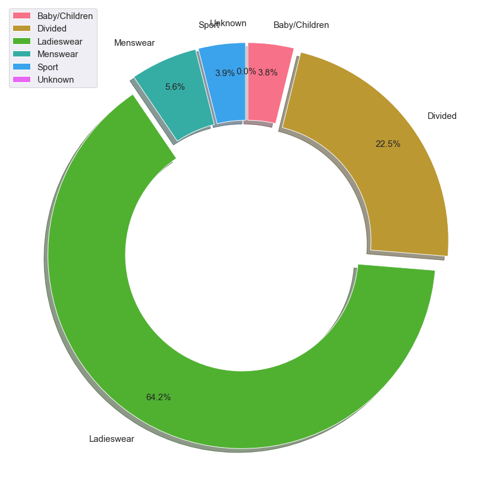

```python
colors = sns.color_palette("husl")
explode = (0.05, 0.05, 0.05, 0.05, 0.05, 0.05)

plt.figure(figsize=(15,15))
plt.pie(x=index_group_revenue['total_revenue'],
        labels=index_group_revenue['index_group_name'],
        autopct='%1.1f%%',
        startangle=90,
        counterclock=False,
        wedgeprops={'width':0.4},
        colors=colors,
        shadow=True,
        pctdistance=0.85,
        explode=explode,);
plt.rcParams['font.size']=15
plt.legend();
```

> **Ladieswear and Divident, which are feminine styles contribute 86.7% of the revenue (64.2% and 22.5% respectively)**

## #1 Bestseller/Top Performer

```python
list(articles[articles['article_id'] == 706016001]['detail_desc'])[0]
```

```
'High-waisted jeans in washed superstretch denim with a zip fly and button, fake front pockets, real back pockets and super-skinny legs.'
```

## Club Member Status

```python
customers.groupby('club_member_status').count()
```

| club_member_status | customer_id | FN | Active | fashion_news_frequency | age | postal_code |
| --- | --- | --- | --- | --- | --- | --- |
| ACTIVE | 1272491 | 470826 | 458452 | 1260566 | 1266255 | 1272491 |
| LEFT CLUB | 467 | 8 | 3 | 467 | 464 | 467 |
| PRE-CREATE | 92960 | 5775 | 5631 | 90911 | 85624 | 92960 |

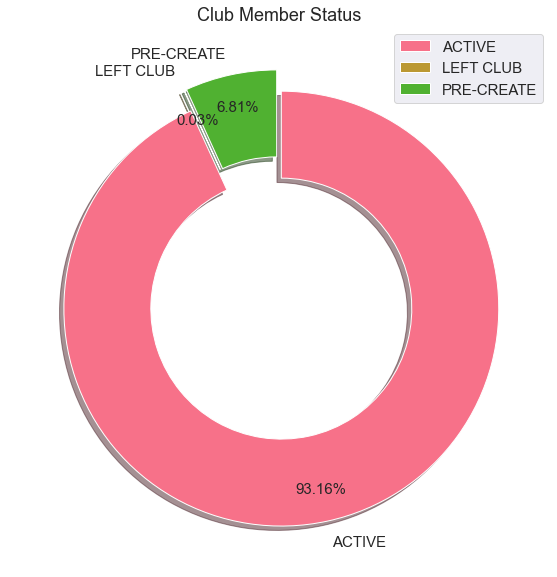

```python
colors = sns.color_palette("husl")
explode = (0.05, 0.05, 0.05)
data = customers.groupby('club_member_status').count()

plt.figure(figsize=(10,10))
plt.pie(data.customer_id,
        labels=data.index,
        autopct='%.2f%%',
        startangle=90,
        counterclock=False,
        wedgeprops={'width':0.4},
        colors=colors,
        shadow=True,
        pctdistance=0.85,
        explode=explode,);
plt.rcParams['font.size']=15
plt.title('Club Member Status')
plt.legend();
```

> **93.16% of the customers are Active members. That brings a positive light to H&M marketing services and quality products**

```python
customers.groupby(['club_member_status', 'age']).count().max()
```

```
customer_id               65487
FN                        26561
Active                    25546
fashion_news_frequency    64965
postal_code               65487
dtype: int64
```

## Purchased Quantity by Customer Analysis

```python
customer_prices=transactions[["customer_id", "price"]].groupby("customer_id").sum()
```

```python
customer_quantity=transactions[["customer_id", "article_id"]].groupby("customer_id").count()
```

```python
customer_quantity_price=pd.merge(customer_prices, customer_quantity, on="customer_id", how="inner")
```

```python
customer_details=pd.merge(customer_quantity_price, customers.drop("postal_code", axis=1), on="customer_id", how="inner")
```

```python
print(f"There are {len(customer_details)} different customers")
```

```
There are 1362281 different customers
```

```python
customer_details.article_id.describe()
```

```
count    1.362281e+06
mean     2.333463e+01
std      3.924225e+01
min      1.000000e+00
25%      3.000000e+00
50%      9.000000e+00
75%      2.700000e+01
max      1.895000e+03
Name: article_id, dtype: float64
```

By calling the "describe" method on the "article_id" column, we can observe that:

- The minimum purchased quantity by a single customer is 1
- 25% of customers Purchased 3 or less items
- 50% of customers Purchased 9 or less items
- 75% of customers Purchased 27 or less items
- The maximum purchased quantity by a single customer is 1895 products

**Let's visualize this**

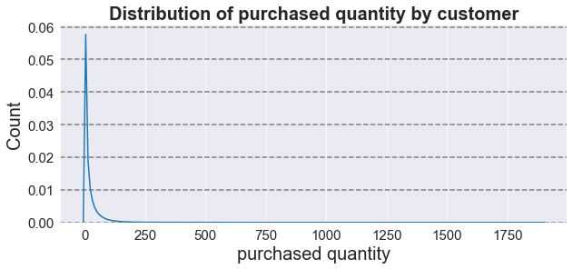

```python
plt.figure(figsize=(10,4))

# Add title
plt.title("Distribution of purchased quantity by customer", fontweight="bold", size=20)
sns.kdeplot(customer_details["article_id"])

# x and y label
plt.xlabel("purchased quantity",fontsize=20)
plt.ylabel("Count",fontsize=20)

plt.grid(axis="y",color = 'grey', linestyle = '--', linewidth = 1.5)

plt.show()
```

> **Do active customers on the fashion news purchase more articles?**

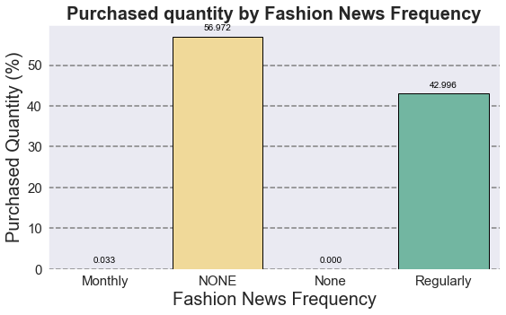

```python
plt.figure(figsize=(9,5))

# Add title and formatting
plt.title("Purchased quantity by Fashion News Frequency", weight="bold", fontsize=20)

g = sns.barplot(x="fashion_news_frequency", y="Purchased Quantity(%)",
                data=customer_details.groupby("fashion_news_frequency")["article_id"].sum() \
            .transform(lambda x: (x / x.sum() * 100)).rename('Purchased Quantity(%)').reset_index(),
                palette="Spectral",
                edgecolor="black")

# Ad x label
plt.xlabel("Fashion News Frequency",fontsize=20)

# Add y label
plt.ylabel("Purchased Quantity (%)", fontsize=20)

for container in g.containers:
    g.bar_label(container,
                padding = 5,
                fmt='%.3f',
                fontsize=10,
                color="black")

plt.grid(axis="y",color = 'grey', linestyle = '--', linewidth = 1.5)
plt.show()
```

## Which age group generates more earnings for the company?

```python
customer_details['age_groups'] = pd.cut(customer_details['age'],
                                        bins=[16, 20, 30, 40,50, 60, 70, float('Inf')],
                                        labels=['16-20', '20-30','30-40','40-50','50-60','60-70' , '70+'])
```

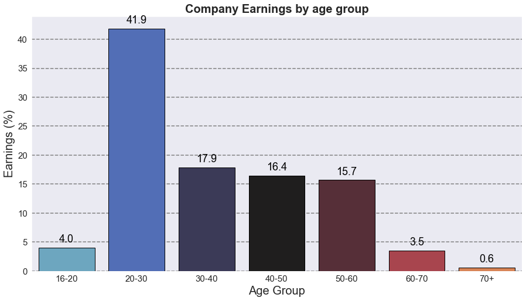

```python
plt.figure(figsize=(15,8))

# plot title
plt.title("Company Earnings by age group", fontweight="bold", size=20)

#plot data
g = sns.barplot(x="age_groups", y="earning(%)",
                data=customer_details.groupby("age_groups")["price"].sum() \
            .transform(lambda x: (x / x.sum() * 100)).rename('earning(%)').reset_index(),
                palette="icefire",
                edgecolor="black")

# x and y labels
plt.xlabel("Age Group",fontsize=20)
plt.ylabel("Earnings (%)",fontsize=20)

for container in g.containers:
    g.bar_label(container, padding = 5, fmt='%.1f', fontsize=18, color="black")


plt.grid(axis="y",color = 'grey', linestyle = '--', linewidth = 1.5)
plt.show()
```

Customers in the range 20-30 are responsible for more than 41% of the total revenue generated. Customers in the range 16-20. 60-70 and 70+ are responsible for the 8% of the total revenue generated products. Customers in the range 30-40, 40-50 and 50-60 are responsible for 16% - 17% of revenue generated each.

> **Let's check the fashion news frequency by age group, to find more useful insights**

```python
x, y = 'age_groups', 'fashion_news_frequency'
age_news = customer_details.groupby(x)[y].value_counts(normalize=True)
age_news = age_news.mul(100)
age_news = age_news.rename('percent(%)').reset_index()
age_news = age_news[age_news["fashion_news_frequency"].isin(["Regularly","NONE"])]
```

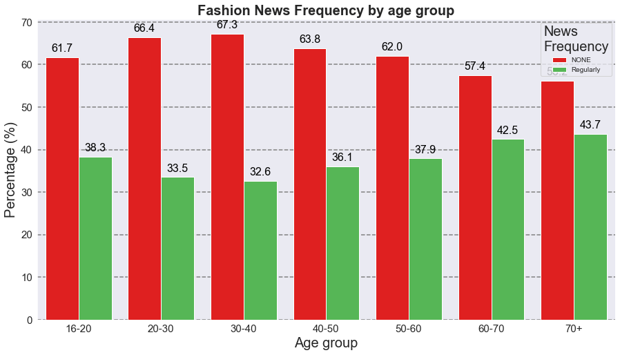

```python
palette1 = {"Regularly":'#46C646', "NONE":'#FF0000'}

plt.figure(figsize=(15,8))

# Add title
plt.title("Fashion News Frequency by age group",weight="bold", size=20)

g=sns.barplot(x="age_groups", y="percent(%)",
              data=age_news,
              hue="fashion_news_frequency",
              palette=palette1)

# x label
plt.xlabel("Age group",fontsize=20)

# y label
plt.ylabel("Percentage (%)",fontsize=20)

for container in g.containers:
    g.bar_label(container, padding = 5, fmt='%.1f', fontsize=16, color="black")

plt.grid(axis="y",color = 'grey', linestyle = '--', linewidth = 1.5)

# Add legend
plt.legend(title='News\nFrequency',
           bbox_to_anchor=(1.0, 1.0),
           ncol=1, fancybox=True,
           shadow=False,
           fontsize=10,
           title_fontsize=20)
plt.show()
```

**We can see that customers in the range 20-30 and 30-40 have the lowest percentage of fashion news frequency, while being the groups which buy the most. Moreover, the frequency of customer that regulary check fashion news starts increasing from the range 40-50, with a peak value of 43.7% of regular/active users for customers in the range 70+ years old. This means that checking fashion news seems to be more effective for older customers, who still represent a small percentage of total sold products, while younger customers do not need to check the news to buy new products. It could be effective for the company to invite younger customers (range 20-40) to check the news more frequently in order to increase the sold items.**

> **Does the club member status influence the purchased quantity?**

```python
customer_details["club_member_status"].value_counts(normalize=True)
```

```
ACTIVE        0.931395
PRE-CREATE    0.068261
LEFT CLUB     0.000344
Name: club_member_status, dtype: float64
```

```python
print("The average quantity of purchased products by the customers is {:.0f} products ".format(customer_details["article_id"].mean()))
```

```
The average quantity of purchased products by the customers is 23 products
```

```python
print("The average quantity of purchased products by the ACTIVE customers is {:.0f} products ".format(customer_details.groupby("club_member_status")["article_id"].mean()["ACTIVE"]))
print("The average quantity of purchased products by the LEFT-CLUB customers is {:.0f} products ".format(customer_details.groupby("club_member_status")["article_id"].mean()["LEFT CLUB"]))
print("The average quantity of purchased products by the PRE-CREATE customers is {:.0f} products ".format(customer_details.groupby("club_member_status")["article_id"].mean()["PRE-CREATE"]))
```

```
The average quantity of purchased products by the ACTIVE customers is 25 products
The average quantity of purchased products by the LEFT-CLUB customers is 18 products
The average quantity of purchased products by the PRE-CREATE customers is 7 products
```

> **Let's visualize these numbers**

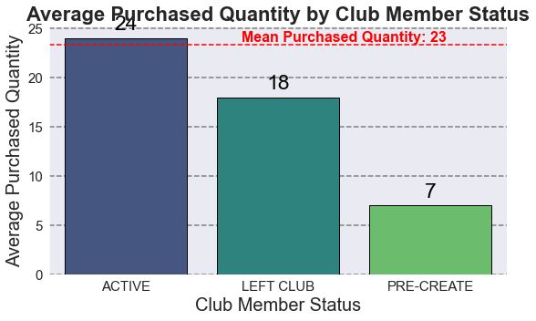

```python
plt.figure(figsize=(9,5))

plt.title("Average Purchased Quantity by Club Member Status", fontweight="bold", size=22)

g = sns.barplot(x="club_member_status",
                y="article_id",
                data=customer_details.groupby("club_member_status")["article_id"].mean().astype(int).reset_index(),
                palette="viridis",
                edgecolor="black")

plt.axhline(y = customer_details["article_id"].mean(),
            color = 'r',
            linestyle = '--')

plt.text(0.76, 23.7,
         'Mean Purchased Quantity: {:.0f}'.format(customer_details["article_id"].mean()),
         size=16,
         color="red",
         fontweight="bold")

plt.xlabel("Club Member Status",fontsize=20)
plt.ylabel("Average Purchased Quantity",fontsize=20)

for container in g.containers:
    g.bar_label(container, padding = 5, fmt='%.0f', fontsize=23, color="black")

plt.grid(axis="y",color = 'grey', linestyle = '--', linewidth = 1.5)
plt.show()
```

Customers belonging to the ACTIVE clubs, purchase more products than other categories

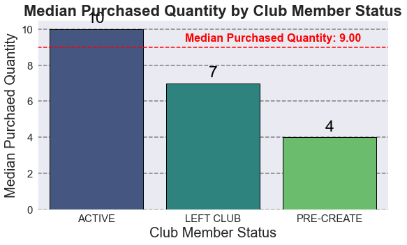

```python
plt.figure(figsize=(9,5))

plt.title("Median Purchased Quantity by Club Member Status", fontweight="bold", size=22)

# plot data
g = sns.barplot(x="club_member_status", y="article_id",
                data=customer_details.groupby("club_member_status")["article_id"].median().reset_index(),
                palette="viridis",
                edgecolor="black")

plt.axhline(y = customer_details["article_id"].median(),
            color = 'r',
            linestyle = '--')

plt.text(0.76, 9.3,
         'Median Purchased Quantity: {:.2f}'.format(customer_details["article_id"].median()),
         size=16,
         color="red",
         fontweight="bold")

# x and y labels
plt.xlabel("Club Member Status",fontsize=20)
plt.ylabel("Median Purchaed Quantity",fontsize=20)

for container in g.containers:
    g.bar_label(container, padding = 5, fmt='%.0f', fontsize=23, color="black")

plt.grid(axis="y",color = 'grey', linestyle = '--', linewidth = 1.5)
plt.show()
```

```python
customer_details.columns
```

```
Index(['customer_id', 'price', 'article_id', 'FN', 'Active',
       'club_member_status', 'fashion_news_frequency', 'age', 'age_groups'],
      dtype='object')
```

> **Let's have a look at the purchased quantity by age group**

```python
customer_details.sample()
```

|  | customer_id | price | article_id | FN | Active | club_member_status | fashion_news_frequency | age | age_groups |
| --- | --- | --- | --- | --- | --- | --- | --- | --- | --- |
| 1241250 | e94d50b9c50e3f6671b8480aea970bc17c771cb8faaf48... | 1.05361 | 27 | NaN | NaN | ACTIVE | NONE | 48.0 | 40-50 |

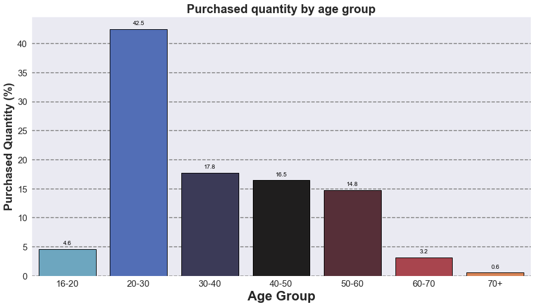

```python
plt.figure(figsize=(15,8))

# Add title
plt.title("Purchased quantity by age group", fontweight="bold", size=20)

# Add plot data
g = sns.barplot(x="age_groups", y="Purchased Quantity(%)",
                data=customer_details.groupby("age_groups")["article_id"].sum() \
                .transform(lambda x: (x / x.sum() * 100)).rename('Purchased Quantity(%)').reset_index(), palette="icefire", edgecolor="black")

# Add x label
plt.xlabel("Age Group",fontweight="bold", size=22)

# Add y label
plt.ylabel("Purchased Quantity (%)",fontweight="bold", size=19)


for container in g.containers:
    g.bar_label(container,
                padding = 5,
                fmt='%.1f',
                fontsize=10,
                color="black")

plt.grid(axis="y",color = 'grey', linestyle = '--', linewidth = 1.5)
plt.show()
```

Customers in the range 20-30 are responsible for more than 42% of the total purchased products. Customers in the range 16-20. 60-70 and 70+ are responsible for the 8% of the total purchased products Customers in the range 30-40, 40-50 and 50-60 are responsible for 16% of purchased quantity each.

## Univariate Transactions Exploration

```python
print(transactions.info())
```

```
<class 'pandas.core.frame.DataFrame'>
RangeIndex: 31788324 entries, 0 to 31788323
Data columns (total 5 columns):
 #   Column            Dtype
---  ------            -----
 0   t_dat             object
 1   customer_id       object
 2   article_id        int64
 3   price             float64
 4   sales_channel_id  int64
dtypes: float64(1), int64(2), object(2)
memory usage: 1.2+ GB
None
```

```python
quantity_sold=transactions["article_id"].value_counts()
quantity_sold.sample()
```

```
791587007    944
Name: article_id, dtype: int64
```

```python
quantity_sold.describe()
```

```
count    104547.000000
mean        304.057735
std         791.266060
min           1.000000
25%          14.000000
50%          65.000000
75%         286.000000
max       50287.000000
Name: article_id, dtype: float64
```

There are 104547 different articles in the transactions. There are items which have been sold only once 25% of sold products, have been sold 14 or less times 50% were sold 65 or less times 75% were sold 286 or less times, The most sold item have been sold 50287 times.

```python
import datetime as dt
```

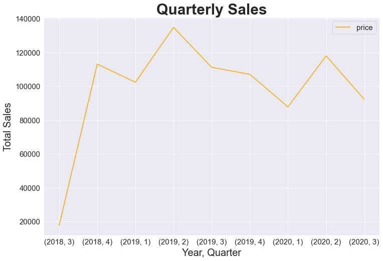

```python
transactions.t_dat = pd.to_datetime(transactions.t_dat)
transactions['quarter'] = transactions.t_dat.dt.quarter
transactions['year'] = transactions.t_dat.dt.year
transactions[['year', 'quarter', 'price']].groupby(['year', 'quarter']).sum().plot(kind='line', color = 'orange', figsize = (12,8))
plt.xlabel('Year, Quarter', fontsize=20)
plt.ylabel('Total Sales', fontsize=20)
plt.title('Quarterly Sales', fontsize=30, weight="bold")
plt.show()
```

> Q2 generates the most revenue. There's a significant drop in sales from 2nd Quarter in 2019 to the 1st Quarter in 2020.

## Bivariate Transactions Exploration

## Number of transactions by index and product categories

> **Let's dive a little deeper to get an understanding of the specifics of the index group names**

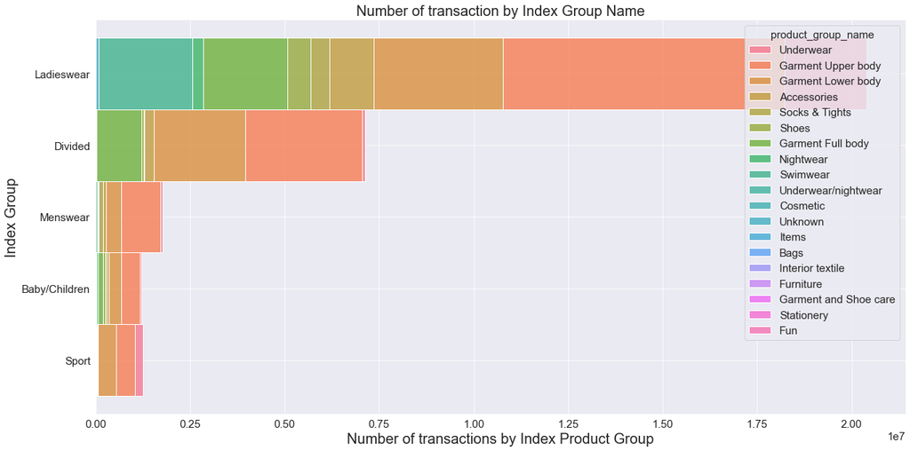

```python
transactions_articles = transactions.merge(articles[['article_id',
                                         'prod_name',
                                         'product_group_name',
                                         'index_group_name']],
                               on = 'article_id',
                               how = 'left')
sns.set_style("darkgrid")
plt.subplots(figsize = (20,10))
sns.histplot(data = transactions_articles,
             y = 'index_group_name',
             hue = 'product_group_name',
             multiple = 'stack')
plt.xlabel('Number of transactions by Index Product Group', fontsize=20)
plt.ylabel('Index Group', fontsize=20)
plt.title('Number of transaction by Index Group Name', fontsize=20)
plt.show()
```

> **The best selling index group is ladieswear. Most of the best selling ladieswear products are upper & lower body garments. Upper & lower body garments are also sold for the rest of the index groups**

#### Let's look at what kind of customers purchase ladieswear products

```python
customers_transactions_articles = transactions_articles.merge(customers, on = 'customer_id', how = 'left')
customers_transactions_articles.head(10)
```

|  | t_dat | customer_id | article_id | price | sales_channel_id | quarter | year | prod_name | product_group_name | index_group_name | FN | Active | club_member_status | fashion_news_frequency | age | postal_code |
| --- | --- | --- | --- | --- | --- | --- | --- | --- | --- | --- | --- | --- | --- | --- | --- | --- |
| 0 | 2018-09-20 | 000058a12d5b43e67d225668fa1f8d618c13dc232df0ca... | 663713001 | 0.050831 | 2 | 3 | 2018 | Atlanta Push Body Harlow | Underwear | Ladieswear | NaN | NaN | ACTIVE | NONE | 24.0 | 64f17e6a330a85798e4998f62d0930d14db8db1c054af6... |
| 1 | 2018-09-20 | 000058a12d5b43e67d225668fa1f8d618c13dc232df0ca... | 541518023 | 0.030492 | 2 | 3 | 2018 | Rae Push (Melbourne) 2p | Underwear | Ladieswear | NaN | NaN | ACTIVE | NONE | 24.0 | 64f17e6a330a85798e4998f62d0930d14db8db1c054af6... |
| 2 | 2018-09-20 | 00007d2de826758b65a93dd24ce629ed66842531df6699... | 505221004 | 0.015237 | 2 | 3 | 2018 | Inca Jumper | Garment Upper body | Divided | 1.0 | 1.0 | ACTIVE | Regularly | 32.0 | 8d6f45050876d059c830a0fe63f1a4c022de279bb68ce3... |
| 3 | 2018-09-20 | 00007d2de826758b65a93dd24ce629ed66842531df6699... | 685687003 | 0.016932 | 2 | 3 | 2018 | W YODA KNIT OL OFFER | Garment Upper body | Ladieswear | 1.0 | 1.0 | ACTIVE | Regularly | 32.0 | 8d6f45050876d059c830a0fe63f1a4c022de279bb68ce3... |
| 4 | 2018-09-20 | 00007d2de826758b65a93dd24ce629ed66842531df6699... | 685687004 | 0.016932 | 2 | 3 | 2018 | W YODA KNIT OL OFFER | Garment Upper body | Ladieswear | 1.0 | 1.0 | ACTIVE | Regularly | 32.0 | 8d6f45050876d059c830a0fe63f1a4c022de279bb68ce3... |
| 5 | 2018-09-20 | 00007d2de826758b65a93dd24ce629ed66842531df6699... | 685687001 | 0.016932 | 2 | 3 | 2018 | W YODA KNIT OL OFFER | Garment Upper body | Ladieswear | 1.0 | 1.0 | ACTIVE | Regularly | 32.0 | 8d6f45050876d059c830a0fe63f1a4c022de279bb68ce3... |
| 6 | 2018-09-20 | 00007d2de826758b65a93dd24ce629ed66842531df6699... | 505221001 | 0.020322 | 2 | 3 | 2018 | Inca jumper | Garment Upper body | Divided | 1.0 | 1.0 | ACTIVE | Regularly | 32.0 | 8d6f45050876d059c830a0fe63f1a4c022de279bb68ce3... |
| 7 | 2018-09-20 | 00083cda041544b2fbb0e0d2905ad17da7cf1007526fb4... | 688873012 | 0.030492 | 1 | 3 | 2018 | Gyda! | Garment Upper body | Ladieswear | NaN | NaN | ACTIVE | NONE | 29.0 | 24e3594738f327e8a7671ec6d1e18b308fb0282e1f7e23... |
| 8 | 2018-09-20 | 00083cda041544b2fbb0e0d2905ad17da7cf1007526fb4... | 501323011 | 0.053373 | 1 | 3 | 2018 | Thomas paperbag wide | Garment Lower body | Ladieswear | NaN | NaN | ACTIVE | NONE | 29.0 | 24e3594738f327e8a7671ec6d1e18b308fb0282e1f7e23... |
| 9 | 2018-09-20 | 00083cda041544b2fbb0e0d2905ad17da7cf1007526fb4... | 598859003 | 0.045746 | 2 | 3 | 2018 | Fiona Wide | Garment Lower body | Ladieswear | NaN | NaN | ACTIVE | NONE | 29.0 | 24e3594738f327e8a7671ec6d1e18b308fb0282e1f7e23... |

```python
#Age groups
def age_categories(age):
    if age is None:
        return "unknown"
    elif age >= 60:
        return "above 60"
    elif age <= 59 and age >= 50:
        return "50-59"
    elif age <= 49 and age >= 40:
        return "40-49"
    elif age <= 39 and age >= 30:
        return "30-39"
    elif age <=29 and age >= 21:
        return "21-29"
    else:
        return "below 21"
customers_transactions_articles['ages'] = customers_transactions_articles['age'].map(lambda x: age_categories(x))
```

## Index Group by Customer Age

```python
#Index Group vs Customer age
data = customers_transactions_articles[['index_group_name', 'ages', 'price']].groupby(['index_group_name','ages']).sum()
data = data.unstack().fillna(0)
plt.subplots(figsize = (10,10))
sns.heatmap(data, cmap="Greens")
plt.title("Relationship between Index Group and Customer Age")
plt.ylabel("Index Group Name")
plt.xlabel("Age Group")
plt.show()
```

[output not shown]

[output cut: 25 more lines]

[output not shown]

# Conclusions

H&M articles has articles has 6 known products. Majority of H&M products are Dark followed by Dusty Light and Light (40.5%, 21% and 14.9% respectively).

The Top bestseller articles have an average sale of ~137 units per day

A review at the H&M official website shows that it targets feminine styles. We can see that most best selling articles were designed for the femal audience.

Although H&M produces baby clothes, none of them made it to the topseller

The #1 Top Performer is a "high-waisted jeans in washed super stretched denim with a zip fly and button, fake pockets, real back pockets and super-skinny legs"

```python
jupyter nbconvert 'H&M Personalized Fashion Recommendations.ipynb' --to slides --post serve
```

[output not shown]